# Spore Storage Experiment Results

Meghan Duffy

6/18/2018

## Basic motivation for study:

Our experience over the years indicates that Metschnikowia and Pasteuria spores respond very differently to storage in the freezer, and also that they differ greatly in how long they can be stored. This experiment was aimed at getting quantitative data on those questions. The basic questions were: 1. What is the best way to store Metschnikowia and Pasteuria spores? 2. How long can spores be stored for while remaining viable? 3. Does freezing kill Metschnikowia spores?

While doing the study, Katie Hunsberger noticed that the counts of spores seemed to be decreasing, at least in some treatments. Therefore, we added an additional question: 4. How does spore storage impact the number of spores recovered from infected hosts?

## Basic methods

At the beginning of the experiment, we grew up a very large number of infected animals. All hosts were the Mid37 genotype. For Metschnikowia, we used our standard lab strain, and for Pasteuria we used our G/18 line.

For Metschnikowia, we used two spore doses, 250 and 1000 spores/mL. For Pasteuria, we used two spore doses, 500 and 2000 spores/mL.

Infected individuals were haphazardly assigned to tubes and tubes were haphazardly assigned to treatments. Spores were stored in the fridge and freezer. However, since our previous work indicated that Metschnikowia spores do not survive freezing, we did not use a fully factorial approach. For the 1 day and 2 week treatments, we had 1000 spores/mL in the freezer treatment. After that, we did not do a freezer treatment for Metschnikowia.

For most cases, there were 3 (for Metschnikowia) or 5 (for Pasteuria) replicate tubes. The number of replicate tubes is indicated in Table 1 in the manuscript; with the exception of the Metschnikowia -20 C treatment (which did not have low spore beakers), a single tube was used to generate the spores for both low spore dose and high spore dose beakers. There were also a few other exceptions, driven by not having enough spores to do the planned replication. Those exceptions are:

1. For the Pasteuria 9 month -20 C treatment, there were not enough spores in one of the replicate tubes for two beakers at the high spore dose. However, for another replicate tube, there were enough spores for four replicate beakers at the high spore dose.
2. For the Pasteuria 4 week 4 C treatment, there was only one beaker for one replicate tube but three beakers for another.
3. For the Pasteuria 6 month 4 C treatment, two replicate tubes had two beakers for each spore dose; a third had four beakers for the low spore dose and two for the high spore dose, while another had none for the low spore dose and two for the high spore dose. The remaining replicate tube had two beakers for the low spore dose and one for the high.
4. For the Pasteuria 9 month 4 C treatment, the replicate tubes had the following combinations of beakers for the low and high spore doses, respectively: 3 and 1, 2 and 1, 2 and 2, 4 and 0, and 3 and 1.
5. For the Pasteuria 1 year 4 C treatment, only one of the replicate tubes had enough spores for two replicate beakers at the high spore dose; one did not have enough spores for any beakers at the high spore dose, while the others had enough spores for one beaker.

## Analysis of Infectivity of Spores

First, load libraries needed below

```r
library(tidyverse)
```

```r
library(cowplot)
```

Then read in data and do some basic manipulations.

```r
sporedata <- read.csv("SporeStorage.csv")
colnames(sporedata)
```

```
##  [1] "Storage.length.rank" "Storage.length"      "Parasite"
##  [4] "Fridge.or.freezer"   "Dose"                "Sticker.color"
##  [7] "Rep"                 "Total.checked"       "Infected"
## [10] "Possible.problem"    "X"                   "X.1"
## [13] "X.2"                 "X.3"                 "X.4"
```

```r
sporedata$reptube <- substr(sporedata$Rep, start = 1, stop = 1)
sporedata$repbeaker <- substr(sporedata$Rep, start = 2, stop = 2)

sporedata$propinf <- sporedata$Infected/sporedata$Total.checked

#NOTE: excluding the one Pasteuria tube that had an oddly low spore count with no explanation noted in lab notebook about how Katie got enough spores to do the exposures
sporedata <- sporedata %>%
  subset(sporedata$Possible.problem < 1)

summarydata <- sporedata %>%
  group_by(Storage.length,Parasite,Dose,Fridge.or.freezer,reptube) %>%
  summarise(sumchecked = sum(Total.checked), suminfected = sum(Infected))

summarydata$propinf <- summarydata$suminfected/summarydata$sumchecked
```

### How did infectivity change over time in the different treatments? First up, plot the data

```r
summarydata$Storage.length <- plyr::mapvalues(summarydata$Storage.length, from = c("1 day","2 weeks","4 weeks","2 months","4 months","6 months","9 months","1 year"), to = c("1 day","2 wks", "4 wks","2 mo.","4 mo.","6 mo.","9 mo.","12 mo."))

summarydata$Storage.length <- factor(summarydata$Storage.length,
                                            c("1 day","2 wks", "4 wks","2 mo.","4 mo.","6 mo.","9 mo.","12 mo."))

summarydata$Parasite <- str_replace(summarydata$Parasite,"Metsch","Metschnikowia")

summarydata$Dose <- as.factor(summarydata$Dose)

summarydata$storagetemp <- plyr::mapvalues(summarydata$Fridge.or.freezer, from = c("Fridge","Freezer"), to = c("4*C", "-20*C"))
```

Let’s make separate Metsch and Pasteuria figures

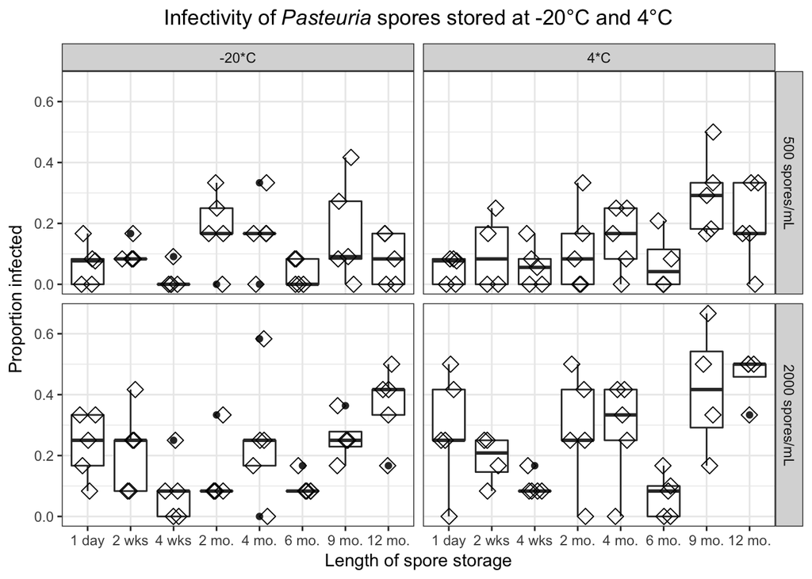

```r
summarydata$Dose <- plyr::mapvalues(summarydata$Dose, from = c("500","2000"), to = c("500 spores/mL", "2000 spores/mL"))

pastplottitle <- expression(paste("Infectivity of"~italic("Pasteuria "),"spores stored at -20°C and 4°C"))

pastplotplusboxplot <- summarydata %>%
  filter(Parasite=="Pasteuria") %>%
  ggplot(aes(x=Storage.length,y=propinf)) +
  geom_boxplot() +
  geom_point(shape=5,size=3,position=position_jitter(width=0.2, height=0)) +
  theme_bw()  + facet_grid(Dose~storagetemp) +
  ggtitle(pastplottitle) +
  theme(plot.title = element_text(hjust = 0.5)) +
  xlab("Length of spore storage") +
  ylab("Proportion infected") +
  theme(legend.position="none")

pastplotplusboxplot
```

```r
save_plot("pastplotplusboxplot.jpg", pastplotplusboxplot, base_width = 8, base_height = 6)
```

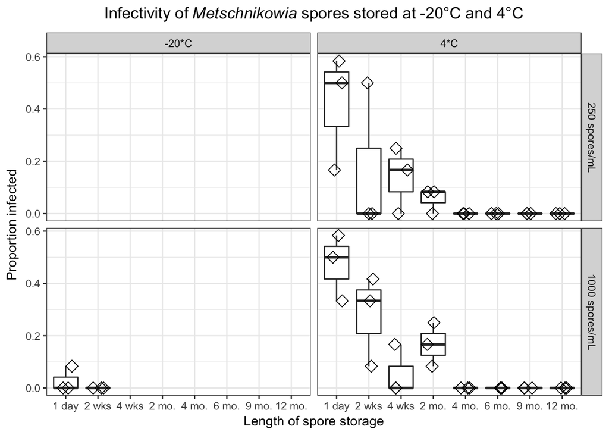

```r
summarydata$Dose <- plyr::mapvalues(summarydata$Dose, from = c("250","1000"), to = c("250 spores/mL", "1000 spores/mL"))

metschplottitle <- expression(paste("Infectivity of"~italic("Metschnikowia "),"spores stored at -20°C and 4°C"))

metschplotplusboxplot <- summarydata %>%
  filter(Parasite=="Metschnikowia") %>%
  ggplot(aes(x=Storage.length,y=propinf)) +
  geom_boxplot() +
  geom_point(shape=5,size=3,position=position_jitter(width=0.2, height=0)) +
  theme_bw()  + facet_grid(Dose~storagetemp) +
  ggtitle(metschplottitle) +
  theme(plot.title = element_text(hjust = 0.5)) +
  xlab("Length of spore storage") +
  ylab("Proportion infected") +
  theme(legend.position="none")

metschplotplusboxplot
```

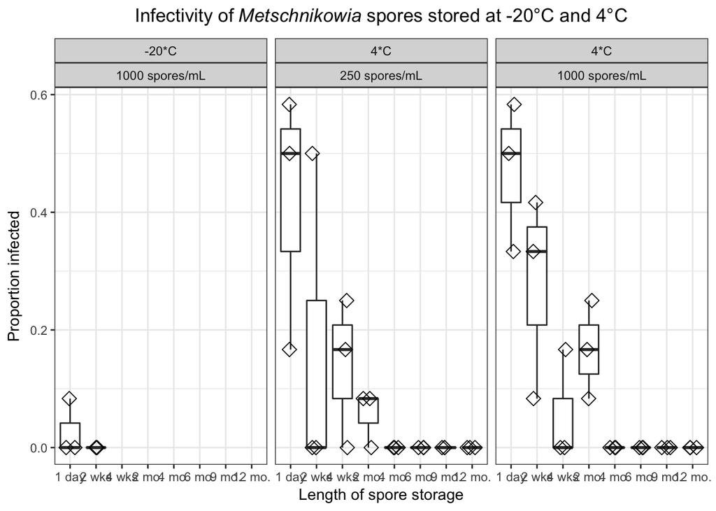

```r
save_plot("metschplotplusboxplot.jpg", metschplotplusboxplot, base_width = 8, base_height = 6)

metschplotplusboxplotwrap <- summarydata %>%
  filter(Parasite=="Metschnikowia") %>%
  ggplot(aes(x=Storage.length,y=propinf)) +
  geom_boxplot() +
  geom_point(shape=5,size=3,position=position_jitter(width=0.2, height=0)) +
  theme_bw()  + facet_wrap(storagetemp~Dose) +
  ggtitle(metschplottitle) +
  theme(plot.title = element_text(hjust = 0.5)) +
  xlab("Length of spore storage") +
  ylab("Proportion infected") +
  theme(legend.position="none")

metschplotplusboxplotwrap
```

```r
save_plot("metschplotplusboxplotwrap.jpg", metschplotplusboxplotwrap, base_width = 10, base_height = 3)
```

### Next, let’s analyze the spore infectivity data

For this, I am analyzing the Metsch fridge data on its own (since there’s no point in analyzing the freezer data). In a second analysis, I am then analyzing the Pasteuria data. For both, I’m using glms with binomial error. For Metsch, the model includes spore dose, storage length (measured in days), and their interaction. For Pasteuria, the model includes spore dose, storage length, storage temperature, plus all their interactions.

I am basing the way I input the response variable on this: http://www.simonqueenborough.info/R/stats-basic/glm.html (scroll down to the proportion infected section). One of the things I’m most interested in thinking about is whether these models seem properly done.

```r
summarydata$lengthdays <- plyr::mapvalues(summarydata$Storage.length, from = c("1 day","2 wks", "4 wks","2 mo.","4 mo.","6 mo.","9 mo.","12 mo."), to = c("1", "14", "28",  "78", "120", "189", "273", "358"))
#str(summarydata)

summarydata$lengthdays <- as.numeric(as.character(summarydata$lengthdays))

#str(summarydata)

summarydata$sumuninfected <- (summarydata$sumchecked - summarydata$suminfected)

metschfridgedata <- summarydata %>%
  subset(Parasite == "Metschnikowia" & Fridge.or.freezer == "Fridge")

# resource for this approach: http://www.simonqueenborough.info/R/stats-basic/glm.html
metschfridgedatay <- cbind(metschfridgedata$suminfected, metschfridgedata$sumuninfected)

metschfridgemodel1<- glm(metschfridgedatay~metschfridgedata$Dose*metschfridgedata$lengthdays,family = binomial)

summary(metschfridgemodel1)
```

```
##
## Call:
## glm(formula = metschfridgedatay ~ metschfridgedata$Dose * metschfridgedata$lengthdays,
##     family = binomial)
##
## Deviance Residuals:
##      Min        1Q    Median        3Q       Max
## -2.58152  -0.38401  -0.08637   0.26097   2.02430
##
## Coefficients:
##                                                                 Estimate
## (Intercept)                                                     -0.60229
## metschfridgedata$Dose1000 spores/mL                              0.10517
## metschfridgedata$lengthdays                                     -0.03835
## metschfridgedata$Dose1000 spores/mL:metschfridgedata$lengthdays  0.01059
##                                                                 Std. Error
## (Intercept)                                                        0.27978
## metschfridgedata$Dose1000 spores/mL                                0.37581
## metschfridgedata$lengthdays                                        0.01071
## metschfridgedata$Dose1000 spores/mL:metschfridgedata$lengthdays    0.01261
##                                                                 z value
## (Intercept)                                                      -2.153
## metschfridgedata$Dose1000 spores/mL                               0.280
## metschfridgedata$lengthdays                                      -3.582
## metschfridgedata$Dose1000 spores/mL:metschfridgedata$lengthdays   0.840
##                                                                 Pr(>|z|)
## (Intercept)                                                     0.031339
## metschfridgedata$Dose1000 spores/mL                             0.779594
## metschfridgedata$lengthdays                                     0.000341
## metschfridgedata$Dose1000 spores/mL:metschfridgedata$lengthdays 0.401050
##
## (Intercept)                                                     *
## metschfridgedata$Dose1000 spores/mL
## metschfridgedata$lengthdays                                     ***
## metschfridgedata$Dose1000 spores/mL:metschfridgedata$lengthdays
## ---
## Signif. codes:  0 '***' 0.001 '**' 0.01 '*' 0.05 '.' 0.1 ' ' 1
##
## (Dispersion parameter for binomial family taken to be 1)
##
##     Null deviance: 170.30  on 47  degrees of freedom
## Residual deviance:  57.42  on 44  degrees of freedom
## AIC: 111.75
##
## Number of Fisher Scoring iterations: 7
```

```r
pastdata <- summarydata %>%
  subset(Parasite == "Pasteuria")

pastdatay <- cbind(pastdata$suminfected, pastdata$sumuninfected)

pastmodel1<- glm(pastdatay~pastdata$storagetemp*pastdata$lengthdays*pastdata$Dose,family = binomial)

summary(pastmodel1)
```

```
##
## Call:
## glm(formula = pastdatay ~ pastdata$storagetemp * pastdata$lengthdays *
##     pastdata$Dose, family = binomial)
##
## Deviance Residuals:
##     Min       1Q   Median       3Q      Max
## -3.3337  -1.2932  -0.1435   0.7361   2.9508
##
## Coefficients:
##                                                                          Estimate
## (Intercept)                                                             -2.299341
## pastdata$storagetemp4*C                                                 -0.207015
## pastdata$lengthdays                                                      0.001000
## pastdata$Dose2000 spores/mL                                              0.598401
## pastdata$storagetemp4*C:pastdata$lengthdays                              0.003160
## pastdata$storagetemp4*C:pastdata$Dose2000 spores/mL                      0.452894
## pastdata$lengthdays:pastdata$Dose2000 spores/mL                          0.001401
## pastdata$storagetemp4*C:pastdata$lengthdays:pastdata$Dose2000 spores/mL -0.002988
##                                                                         Std. Error
## (Intercept)                                                               0.229318
## pastdata$storagetemp4*C                                                   0.328764
## pastdata$lengthdays                                                       0.001210
## pastdata$Dose2000 spores/mL                                               0.290980
## pastdata$storagetemp4*C:pastdata$lengthdays                               0.001570
## pastdata$storagetemp4*C:pastdata$Dose2000 spores/mL                       0.412948
## pastdata$lengthdays:pastdata$Dose2000 spores/mL                           0.001509
## pastdata$storagetemp4*C:pastdata$lengthdays:pastdata$Dose2000 spores/mL   0.002091
##                                                                         z value
## (Intercept)                                                             -10.027
## pastdata$storagetemp4*C                                                  -0.630
## pastdata$lengthdays                                                       0.827
## pastdata$Dose2000 spores/mL                                               2.057
## pastdata$storagetemp4*C:pastdata$lengthdays                               2.013
## pastdata$storagetemp4*C:pastdata$Dose2000 spores/mL                       1.097
## pastdata$lengthdays:pastdata$Dose2000 spores/mL                           0.929
## pastdata$storagetemp4*C:pastdata$lengthdays:pastdata$Dose2000 spores/mL  -1.429
##                                                                         Pr(>|z|)
## (Intercept)                                                               <2e-16
## pastdata$storagetemp4*C                                                   0.5289
```

[output cut: 10 more lines]

```
## pastdata$Dose2000 spores/mL                                             *
## pastdata$storagetemp4*C:pastdata$lengthdays                             *
## pastdata$storagetemp4*C:pastdata$Dose2000 spores/mL
## pastdata$lengthdays:pastdata$Dose2000 spores/mL
## pastdata$storagetemp4*C:pastdata$lengthdays:pastdata$Dose2000 spores/mL
## ---
## Signif. codes:  0 '***' 0.001 '**' 0.01 '*' 0.05 '.' 0.1 ' ' 1
##
## (Dispersion parameter for binomial family taken to be 1)
##
##     Null deviance: 319.23  on 153  degrees of freedom
## Residual deviance: 252.14  on 146  degrees of freedom
## AIC: 559.23
##
## Number of Fisher Scoring iterations: 4
```

### Posthoc analyses to get a better sense of what’s going on with the Pasteuria infectivity data

```r
past500fridgedata <- pastdata %>%
  subset(Dose == "500 spores/mL" & Fridge.or.freezer == "Fridge")

past500fridgedatay <- cbind(past500fridgedata$suminfected, past500fridgedata$sumuninfected)

past500fridgemodel1<- glm(past500fridgedatay~past500fridgedata$lengthdays,family = binomial)

summary(past500fridgemodel1)
```

```
##
## Call:
## glm(formula = past500fridgedatay ~ past500fridgedata$lengthdays,
##     family = binomial)
##
## Deviance Residuals:
##     Min       1Q   Median       3Q      Max
## -3.3337  -1.4017  -0.1931   0.7232   2.2898
##
## Coefficients:
##                                Estimate Std. Error z value Pr(>|z|)
## (Intercept)                  -2.5063553  0.2355818 -10.639  < 2e-16 ***
## past500fridgedata$lengthdays  0.0041602  0.0009998   4.161 3.17e-05 ***
## ---
## Signif. codes:  0 '***' 0.001 '**' 0.01 '*' 0.05 '.' 0.1 ' ' 1
##
## (Dispersion parameter for binomial family taken to be 1)
##
##     Null deviance: 81.325  on 37  degrees of freedom
## Residual deviance: 63.473  on 36  degrees of freedom
## AIC: 132.39
##
## Number of Fisher Scoring iterations: 4
```

```r
past2000fridgedata <- pastdata %>%
  subset(Dose == "2000 spores/mL" & Fridge.or.freezer == "Fridge")

past2000fridgedatay <- cbind(past2000fridgedata$suminfected, past2000fridgedata$sumuninfected)

past2000fridgemodel1<- glm(past2000fridgedatay~past2000fridgedata$lengthdays,family = binomial)

summary(past2000fridgemodel1)
```

```
##
## Call:
## glm(formula = past2000fridgedatay ~ past2000fridgedata$lengthdays,
##     family = binomial)
##
## Deviance Residuals:
##      Min        1Q    Median        3Q       Max
## -2.77894  -1.11946   0.07121   0.65001   2.41668
##
## Coefficients:
##                                Estimate Std. Error z value Pr(>|z|)
## (Intercept)                   -1.455061   0.174236  -8.351   <2e-16 ***
## past2000fridgedata$lengthdays  0.002573   0.001048   2.456   0.0141 *
## ---
## Signif. codes:  0 '***' 0.001 '**' 0.01 '*' 0.05 '.' 0.1 ' ' 1
##
## (Dispersion parameter for binomial family taken to be 1)
##
##     Null deviance: 76.847  on 36  degrees of freedom
## Residual deviance: 70.940  on 35  degrees of freedom
## AIC: 153.7
##
## Number of Fisher Scoring iterations: 4
```

```r
past500freezerdata <- pastdata %>%
  subset(Dose == "500 spores/mL"& Fridge.or.freezer == "Freezer")

past500freezerdatay <- cbind(past500freezerdata$suminfected, past500freezerdata$sumuninfected)

past500freezermodel1<- glm(past500freezerdatay~past500freezerdata$lengthdays,family = binomial)

summary(past500freezermodel1)
```

```
##
## Call:
## glm(formula = past500freezerdatay ~ past500freezerdata$lengthdays,
##     family = binomial)
##
## Deviance Residuals:
##     Min       1Q   Median       3Q      Max
## -1.7178  -1.5351  -0.1468   0.6897   2.6332
##
## Coefficients:
##                               Estimate Std. Error z value Pr(>|z|)
## (Intercept)                   -2.29934    0.22933 -10.026   <2e-16 ***
## past500freezerdata$lengthdays  0.00100    0.00121   0.827    0.408
## ---
## Signif. codes:  0 '***' 0.001 '**' 0.01 '*' 0.05 '.' 0.1 ' ' 1
##
## (Dispersion parameter for binomial family taken to be 1)
##
##     Null deviance: 62.395  on 39  degrees of freedom
## Residual deviance: 61.723  on 38  degrees of freedom
## AIC: 124.67
##
## Number of Fisher Scoring iterations: 5
```

```r
past2000freezerdata <- pastdata %>%
  subset(Dose == "2000 spores/mL" & Fridge.or.freezer == "Freezer")

past2000freezerdatay <- cbind(past2000freezerdata$suminfected, past2000freezerdata$sumuninfected)

past2000freezermodel1<- glm(past2000freezerdatay~past2000freezerdata$lengthdays,family = binomial)

summary(past2000freezermodel1)
```

```
##
## Call:
## glm(formula = past2000freezerdatay ~ past2000freezerdata$lengthdays,
##     family = binomial)
##
## Deviance Residuals:
##     Min       1Q   Median       3Q      Max
## -2.2869  -0.9581  -0.2595   0.8109   2.9508
##
## Coefficients:
##                                  Estimate Std. Error z value Pr(>|z|)
## (Intercept)                    -1.7009399  0.1791157  -9.496  < 2e-16 ***
## past2000freezerdata$lengthdays  0.0024020  0.0009009   2.666  0.00767 **
## ---
## Signif. codes:  0 '***' 0.001 '**' 0.01 '*' 0.05 '.' 0.1 ' ' 1
##
## (Dispersion parameter for binomial family taken to be 1)
##
##     Null deviance: 63.034  on 38  degrees of freedom
## Residual deviance: 56.007  on 37  degrees of freedom
## AIC: 148.47
##
## Number of Fisher Scoring iterations: 4
```

## Analysis of Spore Yield

We weren’t planning on looking at spore yield as a response variable, but, as she did the experiment, Katie noticed that it was getting harder and harder to have enough spores to do the high spore dose treatments. So, we decided to do a post hoc analysis of spore yield.

### How did spore yield change over time in the different treatments? Analyze the data & plot it (plotting second so can make pretty facet labels)

Note: to go from Katie’s spore counts per mL to a number per Daphnia, I first divided by two (since there was 0.5mL per tube) and then by the number of Daphnia that was in the tube (9 for all Metsch fridge treatments, 7 for the Metsch freezer treatments, and 6 for the Pasteuria treatments).

For this, I am once again analyzing the Metsch fridge data on its own (since there’s still no point in analyzing the freezer data). I am then analyzing the Pasteuria data seperately. For both, I’m using glms with normal (gaussian) error. For Metsch, the model includes storage length (measured in days). For Pasteuria, the model includes storage length, storage temperature, and their interaction.

```r
sporecountdata <- read.csv("SporeStorageSporeCounts.csv")
sporecountdata <- subset(sporecountdata, Exclude < 1)

sporecountdata$Fridge.or.freezer <- ifelse(sporecountdata$Storage.Temp == 4,"Fridge","Freezer")

sporecountdata$Storage.Length <- factor(sporecountdata$Storage.Length,
                                            c("1 day","2 wks", "4 wks","2 mo.","4 mo.","6 mo.","9 mo.","12 mo."))

sporecountdata$lengthdays <- plyr::mapvalues(sporecountdata$Storage.Length, from = c("1 day","2 wks", "4 wks","2 mo.","4 mo.","6 mo.","9 mo.","12 mo."), to = c("1", "14", "28",  "78", "120", "189", "273", "358"))

sporecountdata$lengthdays <- as.numeric(as.character(sporecountdata$lengthdays))


metschfridgesporedata <- sporecountdata %>%
  subset(sporecountdata$Parasite == "Metsch" & sporecountdata$Fridge.or.freezer == "Fridge")

metschfridgesporedata$lnSporesperDaphnia <- log(metschfridgesporedata$Spores.per.Daphnia)
metschfridgesporemodel1 <- lm(lnSporesperDaphnia~lengthdays,data=metschfridgesporedata)
summary(metschfridgesporemodel1)
```

```
##
## Call:
## lm(formula = lnSporesperDaphnia ~ lengthdays, data = metschfridgesporedata)
##
## Residuals:
##      Min       1Q   Median       3Q      Max
## -0.28776 -0.10547 -0.05282  0.14374  0.29040
##
## Coefficients:
##               Estimate Std. Error t value Pr(>|t|)
## (Intercept) 10.5908715  0.0580008 182.599   <2e-16 ***
## lengthdays  -0.0004277  0.0003433  -1.246    0.229
## ---
## Signif. codes:  0 '***' 0.001 '**' 0.01 '*' 0.05 '.' 0.1 ' ' 1
##
## Residual standard error: 0.1768 on 18 degrees of freedom
## Multiple R-squared:  0.07937,    Adjusted R-squared:  0.02823
## F-statistic: 1.552 on 1 and 18 DF,  p-value: 0.2288
```

```r
pastsporedata <- sporecountdata %>%
  subset(sporecountdata$Parasite == "Pasteuria")

pastsporedata$lnSporesperDaphnia <- log(pastsporedata$Spores.per.Daphnia)
pastsporemodel1<- glm(lnSporesperDaphnia~lengthdays*Fridge.or.freezer,family = gaussian,data=pastsporedata)

summary(pastsporemodel1)
```

```
##
## Call:
## glm(formula = lnSporesperDaphnia ~ lengthdays * Fridge.or.freezer,
##     family = gaussian, data = pastsporedata)
##
## Deviance Residuals:
##      Min        1Q    Median        3Q       Max
## -1.20340  -0.16416   0.02078   0.19716   0.77954
##
## Coefficients:
##                                      Estimate Std. Error t value Pr(>|t|)
## (Intercept)                        12.0346240  0.0746827 161.143  < 2e-16
## lengthdays                         -0.0011780  0.0004144  -2.843  0.00576
## Fridge.or.freezerFridge            -0.2153667  0.1056374  -2.039  0.04500
## lengthdays:Fridge.or.freezerFridge -0.0014796  0.0005911  -2.503  0.01449
##
## (Intercept)                        ***
## lengthdays                         **
## Fridge.or.freezerFridge            *
## lengthdays:Fridge.or.freezerFridge *
## ---
## Signif. codes:  0 '***' 0.001 '**' 0.01 '*' 0.05 '.' 0.1 ' ' 1
##
## (Dispersion parameter for gaussian family taken to be 0.1022996)
##
##     Null deviance: 15.7566  on 78  degrees of freedom
## Residual deviance:  7.6725  on 75  degrees of freedom
## AIC: 49.979
##
## Number of Fisher Scoring iterations: 2
```

```r
#Now looking to see if the decline is significant even in the freezer:
pastfreezersporedata <- pastsporedata %>%
  subset(pastsporedata$Fridge.or.freezer == "Freezer")

pastfreezersporemodel1<- glm(lnSporesperDaphnia~lengthdays,family = gaussian,data=pastfreezersporedata)

summary(pastfreezersporemodel1)
```

```
##
## Call:
## glm(formula = lnSporesperDaphnia ~ lengthdays, family = gaussian,
##     data = pastfreezersporedata)
##
## Deviance Residuals:
##      Min        1Q    Median        3Q       Max
## -1.20340  -0.17147   0.02374   0.22823   0.51442
##
## Coefficients:
##               Estimate Std. Error t value Pr(>|t|)
## (Intercept) 12.0346240  0.0790399 152.260   <2e-16 ***
## lengthdays  -0.0011780  0.0004385  -2.686   0.0107 *
## ---
## Signif. codes:  0 '***' 0.001 '**' 0.01 '*' 0.05 '.' 0.1 ' ' 1
##
## (Dispersion parameter for gaussian family taken to be 0.1145846)
##
##     Null deviance: 5.1811  on 39  degrees of freedom
## Residual deviance: 4.3542  on 38  degrees of freedom
## AIC: 30.806
##
## Number of Fisher Scoring iterations: 2
```

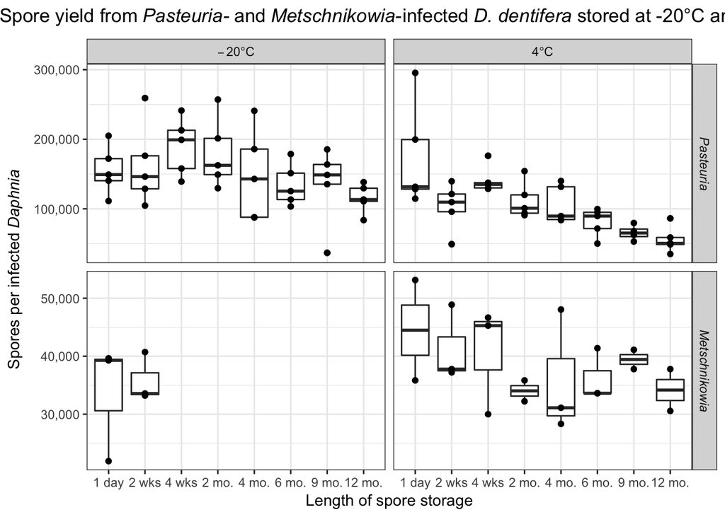

```r
sporecountdata$Parasite <- plyr::mapvalues(sporecountdata$Parasite, from = c("Pasteuria","Metsch"), to = c("italic('Pasteuria')","italic('Metschnikowia')"))

sporecountdata$Storage.Temp <- plyr::mapvalues(sporecountdata$Storage.Temp, from = c("4","-20"), to = c("4*degree*C","-20*degree*C"))

sporecountdata$Spores.per.Daphnia.div <- sporecountdata$Spores.per.Daphnia/1000

sporecountdata$Parasite <- factor(sporecountdata$Parasite,
                                  c("italic('Pasteuria')","italic('Metschnikowia')"))

sporeplottitle <- expression(paste("Spore yield from"~italic("Pasteuria- "),"and"~italic("Metschnikowia-"),"infected"~italic("D. dentifera "),"stored at -20°C and 4°C"))

point <- scales::format_format(big.mark = ",", scientific = FALSE)

sporecountboxplot <- sporecountdata %>%
  ggplot(aes(x=Storage.Length,y=Spores.per.Daphnia)) +
  geom_boxplot() +
  geom_point() +
  theme_bw()  + facet_grid(Parasite~Storage.Temp, scales="free_y",labeller=label_parsed) +
  ggtitle(sporeplottitle) +
  theme(plot.title = element_text(hjust = 0.5)) +
  scale_y_continuous(labels = point) +
#  scale_y_continuous(labels=scales::scientific) +
  xlab("Length of spore storage") +
  ylab(expression(paste("Spores per infected"~italic("Daphnia "))))

sporecountboxplot
```

```r
save_plot("sporecountboxplot.jpg", sporecountboxplot, base_width = 9, base_height = 4)
```